“Vaginal explant herpes infection experiment”

EXPERIMENT NOTES

6 samples failed when the microarray was run (6, 33, 34, 35, 45, 63) and two failed QC (36,64).

FAILED SAMPLES 6 One of the T-cell samples, not included in the explant study

33 ID326 3hr MOCK

34 ID 326 8hr SD90

35 ID 326 24hr V186

36 ID 317 8hr MOCK

45 ID 318 24hr SD90

63 ID 327 8hr SD90

64 ID 319 8hr MOCK

Samples that failed the finalReport file were not included in the report we got from shared resources and I removed the ones that failed QC.

ALSO

The first 6 samples in the micrarray data are T cells that were exposed to Tenofovir. These will be analyzed separately so I removed them from the data set here.

SOME PLOTS OF NON NORMALIZED DATA: density plot, cdf plot, sample relations

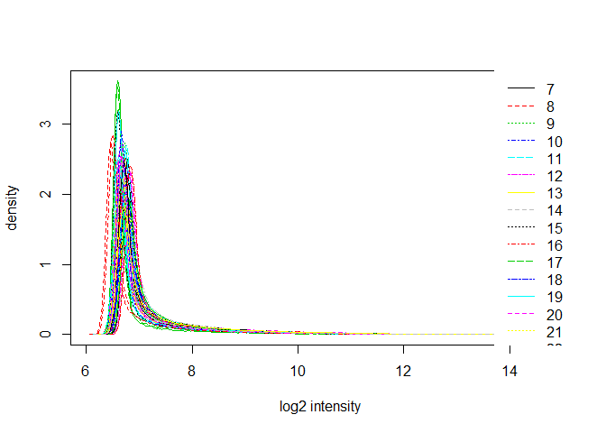

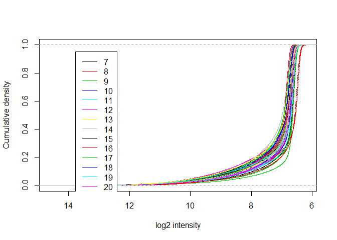

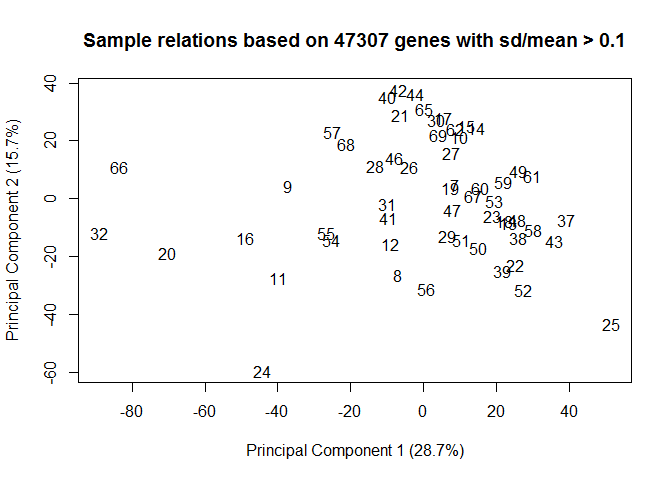

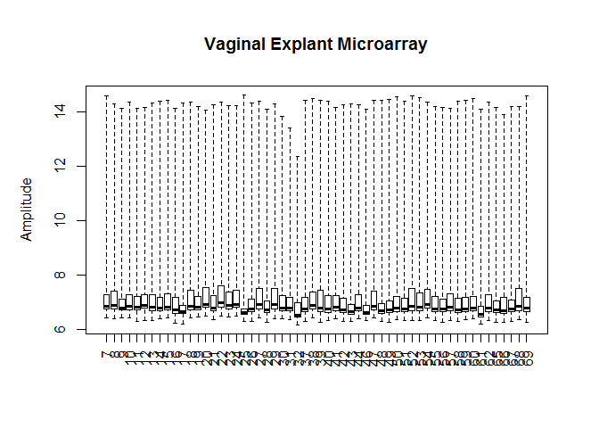

PLOTS OF NORMALIZED DATA

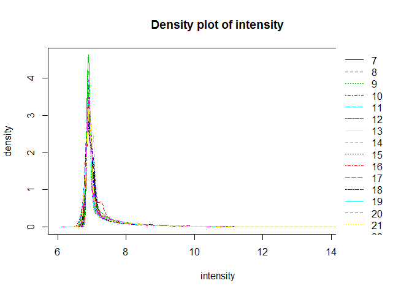

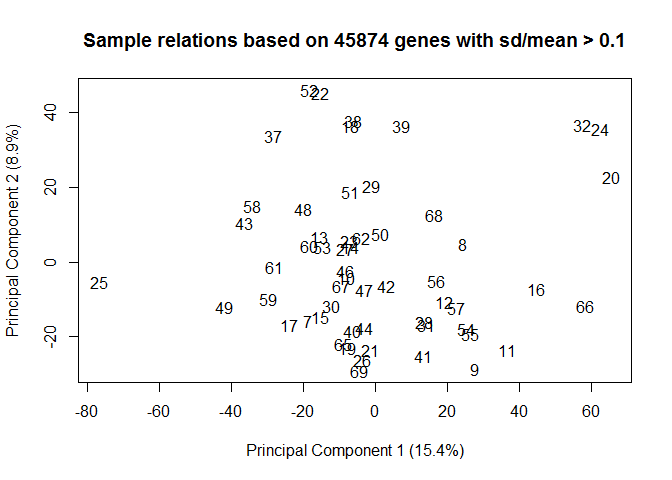

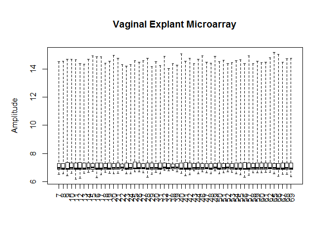

FILTERING PROBES Limma suggests to keep probes that are expressed above background on at least n arrays where n is smallest number of replicates assigned to any of the treatment combinations.

Number of probes in data set before filtering:

```
## [1] 47323
```

Number of probes in data set after filtering:

```
## [1] 27126
```

Number of probes removed by filtering:

```
## [1] 20197
```

The design matrix includes a combined treatment + timepoint parameter (Treat) and a donor parameter (TissueID).

Then we choose the comparisons we want to analyze. I will compare treatment + timepoint condition with the corresponding mock infection in the same donor. This gives 6 contrasts to analyze:

V186.3vsMock.3

V186.8vsMock.8

V186.24vsMock.24

SD90.3vsMock.3

SD90.8vsMock.8

SD90.24vsMock.24

After fitting the contrasts to the model using our design matrix, we can see how many probes are up and down-regulated for each contrast, based on a p-value cut-off of 0.05 and a log-fold-change cut-off of 0.5.

| variable | down | up |
| --- | --- | --- |
| V186.3vsMock.3 | 12 | 10 |
| V186.8vsMock.8 | 8 | 1 |
| V186.24vsMock.24 | 993 | 534 |
| SD90.3vsMock.3 | 2 | 0 |
| SD90.8vsMock.8 | 0 | 0 |
| SD90.24vsMock.24 | 0 | 0 |

Heatmaps of the first 4 contrasts (the only ones with DE probes):

V186 vs mock at 3hr

SD90 vs Mock at 3 hrs. Last plot is of the same probes found to be DE in V186.24vsMock but looking at their expression in the SD90.24vsMock condition, just to see if there is a similar pattern.

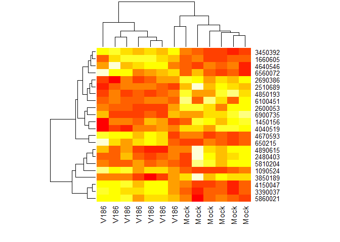

V186 vs mock at 8hr

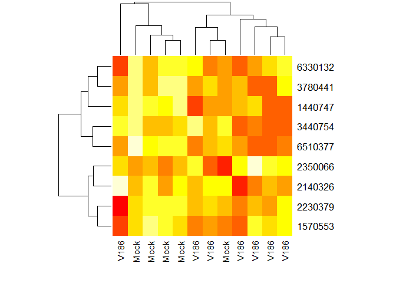

V186 vs mock at 24hr

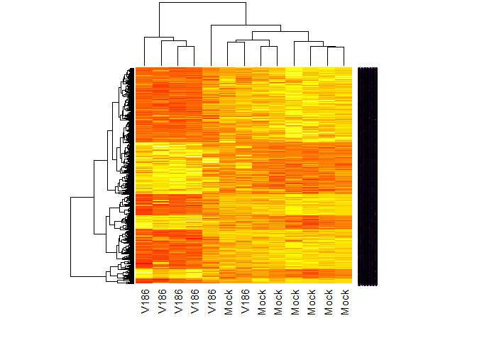

SD90vsMock at 3hr

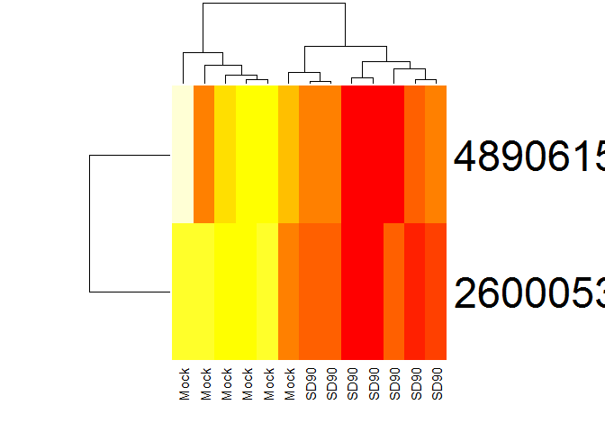

SD90vsMock at 24hrs, but showing the probes that were DE at that time for V186, just to see if there are similar trends.

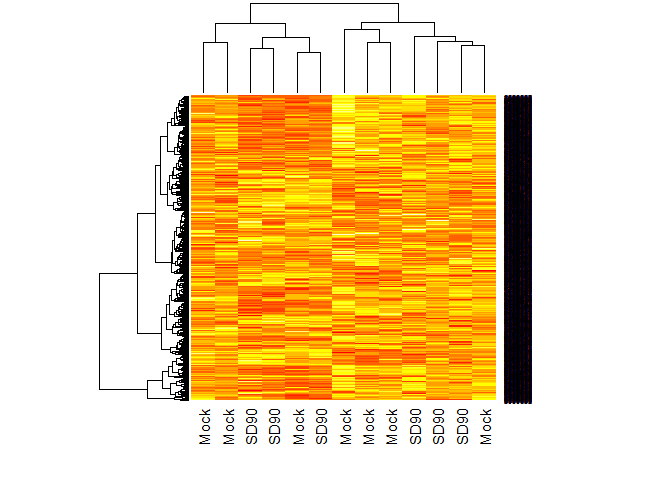

Not really similar.

Next I used InnateDB to do GO and Pathway overrepresentation analyses for the V186.24 vs Mock condition for up and down regulated probes.

Below are the top 10 results. I used the Benjamini-Hochberg p-value correction.

- **GOV186.24DOWN**:

  | GO Term | Corrected P Value |
  | --- | --- |
  | nucleus | 5.136e-10 |
  | regulation of transcription, DNA-templated | 5.526e-06 |
  | DNA binding | 8.286e-06 |
  | cellular protein metabolic process | 0.0004004 |
  | chaperone-mediated protein folding | 0.0006165 |
  | transcription, DNA-templated | 0.001007 |
  | nucleoplasm | 0.001031 |
  | poly(A) RNA binding | 0.001657 |
  | intracellular | 0.003472 |
  | peptidyl-prolyl cis-trans isomerase activity | 0.003597 |

- **GOV186.24UP**:

  | GO Term | Corrected P Value |
  | --- | --- |
  | cytosol | 4.221e-16 |
  | extracellular vesicular exosome | 8.374e-16 |
  | viral process | 5.939e-13 |
  | translation | 5.958e-12 |
  | SRP-dependent cotranslational protein targeting to membrane | 2.519e-11 |
  | translational elongation | 3.324e-10 |
  | cellular protein metabolic process | 4.728e-09 |
  | cytoplasm | 4.318e-08 |
  | poly(A) RNA binding | 4.466e-08 |
  | viral transcription | 8.439e-08 |

- **pathwayV186.24DOWN**:

  | Pathway Name | Corrected P Value |
  | --- | --- |
  | Gene Expression | 4.827e-06 |
  | Generic Transcription Pathway | 0.0001188 |
  | Loss of Function of SMAD2/3 in Cancer | 0.009631 |
  | Loss of Function of SMAD4 in Cancer | 0.009631 |
  | Loss of Function of TGFBR1 in Cancer | 0.009631 |
  | Loss of Function of TGFBR2 in Cancer | 0.009631 |
  | Regulation of nuclear SMAD2/3 signaling | 0.009631 |
  | SMAD2/3 MH2 Domain Mutants in Cancer | 0.009631 |
  | SMAD2/3 Phosphorylation Motif Mutants in Cancer | 0.009631 |
  | SMAD4 MH2 Domain Mutants in Cancer | 0.009631 |

- **pathwayV186.24UP**:

  | Pathway Name | Corrected P Value |
  | --- | --- |
  | Translation | 3.282e-11 |
  | SRP-dependent cotranslational protein targeting to membrane | 1.389e-10 |
  | Eukaryotic Translation Elongation | 2.286e-09 |
  | Peptide chain elongation | 7.935e-09 |
  | Ribosome | 3.962e-07 |
  | Eukaryotic Translation Termination | 4.145e-07 |
  | Viral mRNA Translation | 4.145e-07 |
  | Nonsense Mediated Decay (NMD) independent of the Exon Junction Complex (EJC) | 8.315e-07 |
  | L13a-mediated translational silencing of Ceruloplasmin expression | 9.128e-07 |
  | GTP hydrolysis and joining of the 60S ribosomal subunit | 9.468e-07 |